# STAT/MATH 495: Problem Set 05

Harrison Marick, Christien Wright

2017-10-11

# Collaboration

Please indicate who you collaborated with on this assignment:

Nobody

# Exploratory Data Analysis

Information on the competition can be found [here](https://www.kaggle.com/c/bike-sharing-demand).

Before examining any relationships between variables, we looked at the distribution of the number of bike rentals.

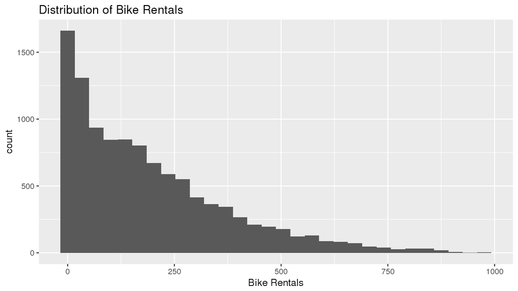

```r
ggplot(train, aes(count)) + geom_histogram() + ggtitle("Distribution of Bike Rentals") + xlab("Bike Rentals")
```

Notice the severe right skew on this dataset. This indicates that it might be useful to apply a log() transformation to our response variable when creating our model.

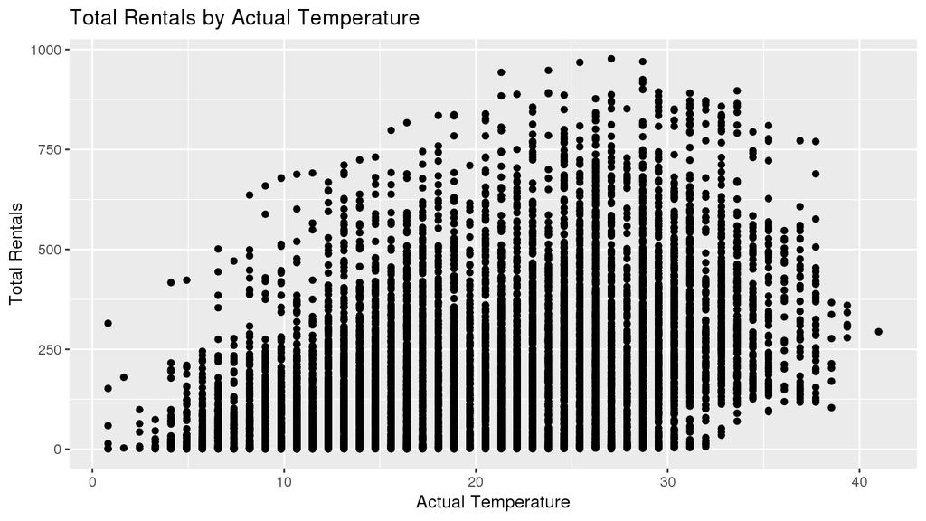

```r
cor(train$count, train[,6]) #correlation b/w temp and count
```

```
##           temp
## [1,] 0.3944536
```

This trend makes sense, intuitively, as people prefer to be outside on warmer days. This trend breaks down slightly as the temperature gets really hot, but the overall trend is generally positive.

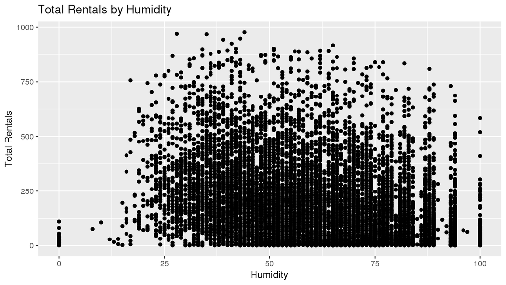

The relationship between humidity and total rentals seems to be negative. The correlation appears to be weaker than that between temperature and total rentals, which we verified below to be -0.32.

```r
cor(train$count, train[,8]) #correlation b/w humidity and count
```

```
##        humidity
## [1,] -0.3173715
```

Like with actual temperature, this trend matches our intuition. Very humid days tend to either be rainy days or hot and “sticky”, neither of which makes for good bike riding weather.

Together, actual temperature and humidity make a more precise version of the weather categorical variable included in the set. Similarly, we elected not to use the season variable because season is essentially a very generally variable that indicates weather.

```r
train$datetime = structure(train$datetime,class=c('POSIXt','POSIXct')) #restructuring
train=mutate(train, time=format(datetime, "%H"))
hour_counts<-train %>% #getting mean rentals by hour of day
  group_by(time) %>%
  summarise(count=mean(count))
```

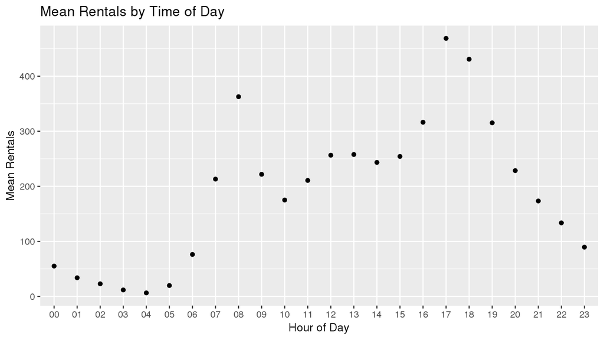

The categorical variable we looked most seriously was the actual time stamp. Instead of using the time stamp as simply an identifier, we felt it might be useful as a categorical variable. Notice in the graph above the arc of the mean bike rentals as the day progresses. Naturally, the middle of the night is the quietest time to see people riding their bikes, while the most popular times are just before and just following work (8 AM and 5/6PM). For this clear trend, we felt that time of day would be useful in our model.

We initiailly expected to include the workingday indicator variable in our model, expecting a significant difference between bike rental volume on work days versus non-working days.

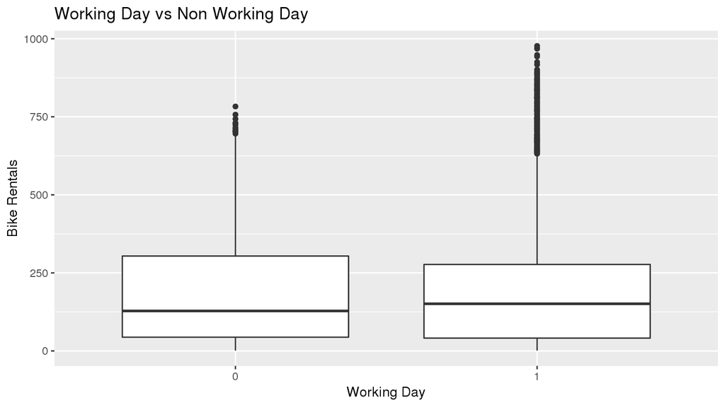

We expected to see significantly more bike rentals on non working days than working days, but the graph above indicates that our suspicians were incorrect.

# Model Fit

```r
mod<-lm(log(count)~temp+humidity+as.factor(time), data=train)
```

Ultimately, we elected to fit a linear model with temperature, humidity, and time of day. In order to ensure that the distribution of bike rentals was not significantly right skewed, we took the log() of the total bike rentals. In addition, this transformation ensured that our predictions are always positive. The $R^2$ value for this model was 0.7692, which indicates that our model learned the training set well. Naturally, the concern with an $R^2$ value this high is that we may be overfitting a specific training set. Having said that, with only 3 variables that should impact bike rentals universally, overfitting should not be an issue here.

# Create Submission File

```r
test$datetime = structure(test$datetime,class=c('POSIXt','POSIXct'))
test=mutate(test, time=format(datetime, "%H"))
test$pred<-exp(predict.lm(mod, test)) #create predictions for test set
submission<-test[,c(1,11)] #select just columns we want
colnames(submission)[2]="count" #renaming
write.csv(submission, "submission.csv", row.names=FALSE) #write to file
```